# Analysis of vehicle frequency in Cross City tunnel

Project 2

530478294

University of Sydney | MATH1005 | Lab Class Thursday 4-5pm

# 1 Executive Summary

As a city revolved around business and tourism, traffic is an inevitable in the city of Sydney, especially in the Inner-West and CBD, hence why we have state-of-the-art roads and tunnels. As a result, alot of data is collected by transport authorites that provides us insight into traffic behaviour and the general community.

In our study we analyse how the volume of vehicles change over each weekday and how the volume of cars has changed due to the start of the COVID Pandemic, providing interesting results that could be used for further research and applied into real-world applications by transport authorites, engineers and more.

# 2 Full Report

## 2.1 Initial Data Analysis (IDA)

### 2.1.1 Source

The dataset “traffic” is a source from NSW Toll Road Data, which is responsible for recording vehicles that pass through toll collection points and records them in a series of 15 min intervals 24/7. Specifically the dataset contains data from the months of March-2019 and March-2020. This is a reliable source from the government making it sufficient for our study

### 2.1.2 Variables

The dataset originally consisted of 14 variables and approximately 36000 entries. However after cleaning and removing unecessary variables, the ‘cleaned’ dataset consisted off 7 variables and approximately 17856 entries.

The alterations made to the dataset included mostly removing variables that we will not use in our study. For example, Gantry entries, Gantry locations and toll points were useless to our study.

We also removed any Vehicle classes related to trucks for easier calculations and also for the fact that they are basically irrelevant to our calculations as so little use the tunnel compared to cars. Although it will have no effect on our conclusion to each research question it might affect calculations slightly.

This dataset is for utmost importance for Transport authorities for a number of reasons. For example, transport authorities to to in make informed decisions about traffic signal timing, lane closures, or other traffic management strategies for reduced travel times.

Transport authorities and engineers can also use the data to take into account of when is the best time to work on designed transportation infrastructure and do any necessary service. An increased amount of cars also results in an increase in pollution and expelling of trapped greenhouse gasses, which are usually extracted using special factories, so it is essential to know when the factory should increase or decrease Carbon Dioxide intake.

Highway Police might also use this dataset to know when to increase restrictions on the road and when to employ things such as double-demirit points

####Cleaning the data

Firstly, we must read the CSV file

```r
read_csv = read.csv('traffic.csv')
```

We will remove any unecessary variables in our dataset and will be irrelevant to our analysis (like Version). The ‘cleaned’ dataset will be the dataset that includes the significant data that will be analysed.

```r
cleaned <- subset(read_csv, select = -c(AssetID, TollPointID, Version, GantryGPSLatitude, GantryGPSLongitude, GantryType, GantryLocation))
cleaned <- subset(cleaned, VehicleClass=='Car')
cleaned <- subset(cleaned, select = -c(VehicleClass))
```

Converting the dates into a useable format

```r
cleaned$Date <- as.Date(cleaned$Date)
cleaned$weekday <- weekdays(cleaned$Date)
```

###Variable summary (for cleaned dataset)

```r
str(cleaned)
```

```
## 'data.frame':    17856 obs. of  7 variables:
##  $ FinancialQtrID : int  201903 201903 201903 201903 201903 201903 201903 201903 201903 201903 ...
##  $ Date           : Date, format: "2019-03-01" "2019-03-01" ...
##  $ IntervalStart  : chr  "00:00" "00:00" "00:00" "00:15" ...
##  $ IntervalEnd    : chr  "00:14" "00:14" "00:14" "00:29" ...
##  $ GantryDirection: chr  "E" "N" "W" "E" ...
##  $ TotalVolume    : int  23 10 18 21 6 22 11 5 12 13 ...
##  $ weekday        : chr  "Friday" "Friday" "Friday" "Friday" ...
```

```r
summary(cleaned)
```

```
##  FinancialQtrID        Date            IntervalStart      IntervalEnd
##  Min.   :201903   Min.   :2019-03-01   Length:17856       Length:17856
##  1st Qu.:201903   1st Qu.:2019-03-16   Class :character   Class :character
##  Median :201953   Median :2019-09-15   Mode  :character   Mode  :character
##  Mean   :201953   Mean   :2019-09-15
##  3rd Qu.:202003   3rd Qu.:2020-03-16
##  Max.   :202003   Max.   :2020-03-31
##  GantryDirection     TotalVolume      weekday
##  Length:17856       Min.   :  0.0   Length:17856
##  Class :character   1st Qu.: 26.0   Class :character
##  Mode  :character   Median :111.0   Mode  :character
##                     Mean   :129.2
##                     3rd Qu.:221.0
##                     Max.   :467.0
```

## 2.2 Research Question 1: Does the volume of cars change during the weekend?

The CCT is a popular tunnel that connects the inner west to the city. It is used by many cars daily and provides compelling data on the trends of traffic in the city. For our hypothesis, we want our data to be accurate in the case of emergency (as said in IDA), so our significance level for the hypothesis testing will be 0.01 meaning the confidence interval is 99%. It is hypothesised that the weekend will as a result in an average 10% increase in the volume of cars on Saturday and Sunday passing through the tunnel as most people use the weekend as a time of relaxation and to go on weekend-trips, so logically more cars will be on the road and hence more people will use the tunnel.

###Hypothesis Null-Hypothesis (H0): P≥0.1

Alternative-Hypothesis (H1): P<0.1

###Assumptions - Each event of a car passing through the tunnel is mutually exclusive - The sample mean has normality (‘cleaned’ dataset has a large enough dataset to accurately model the central limit theorem)

We will use aggregate() function to extract the average of volume of cars going through CCT for each weekday

```r
df1 = cleaned
daily_avg_volume <- aggregate(TotalVolume ~ Date, data = df1, FUN = mean)

daily_avg_volume$Weekday <- weekdays(daily_avg_volume$Date)

# Use aggregate to calculate the average volume for each weekday
weekday_avg_volume <- aggregate(TotalVolume ~ Weekday, data = daily_avg_volume, FUN = mean)


# Reorder the data in terms of the weekdays
desired_order <- c("Monday", "Tuesday", "Wednesday", "Thursday", "Friday", "Saturday", "Sunday")
weekday_avg_volume$Weekday <- factor(weekday_avg_volume$Weekday, levels = desired_order)
weekday_avg_volume <- weekday_avg_volume[order(weekday_avg_volume$Weekday), ]
```

###Graphical summaries

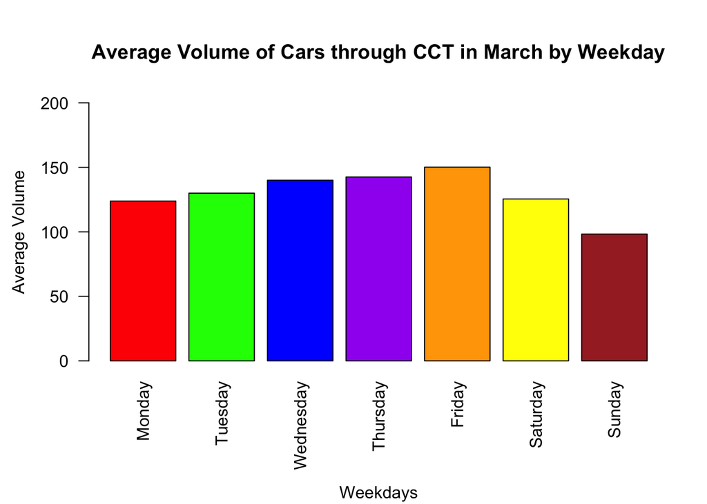

```r
par(mar = c(7.1, 4.4, 5.1, 1.9))
colors <- c("red", "green", "blue", "purple", "orange", "yellow", "brown")

plot.new()

par(new = TRUE)
barplot(weekday_avg_volume$TotalVolume, names.arg = weekday_avg_volume$Weekday,
        main = "Average Volume of Cars through CCT in March by Weekday",
        xlab = "", ylab = "Average Volume", col = colors, border = "black", las = 2, ylim = c(0,200))

mtext("Weekdays", side=1, line=6)
```

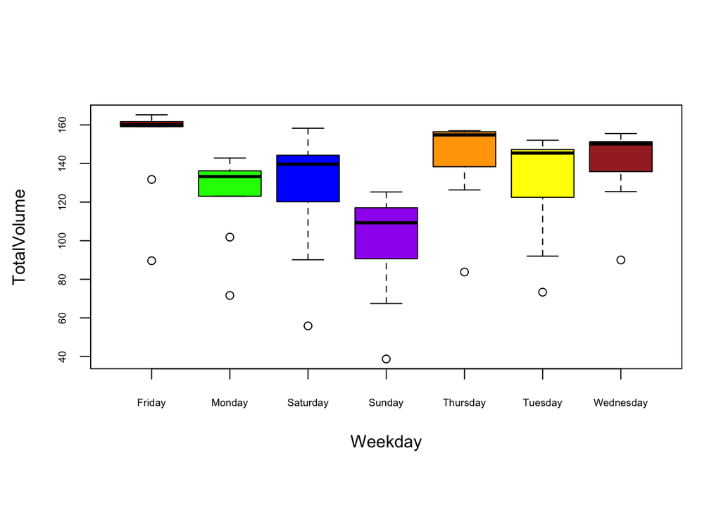

```r
boxplot(TotalVolume ~ Weekday, data = daily_avg_volume,cex.axis = 0.6, col = colors)
```

From the barplot, it is possible to deduce that there is a subtle difference between the average volume of cars passing through the tunnel in the weekdays and the weekends, as Friday has the highest average of 150+ cars passing through CCT at any given 15 minute interval, while Saturdays and Sundays have below average traffic congestion at any given interval, having an average of 125 and 98 cars respectively passing through for each interval. This implies that there is a negative correlation between the volume of cars passing through the tunnel between weekends and weekdays and provides evidence to reject the null-hypothesis.

###t-test For further analysis, we used a t-test

```r
x <- daily_avg_volume$TotalVolume
EV = 1.1*mean(daily_avg_volume$TotalVolume)

# Perform a two-sample t-test with equal variances
t.test(x, alternative = "two.sided", mu = EV, conf.level = 0.99)
```

```
##
##  One Sample t-test
##
## data:  x
## t = -3.3844, df = 61, p-value = 0.001252
## alternative hypothesis: true mean is not equal to 142.0753
## 99 percent confidence interval:
##  119.0124 139.3063
## sample estimates:
## mean of x
##  129.1593
```

Further research research into the topic unveiled a report from the Sydney Morning Herald, where they sated “In 2016, Sydney’s weekday peak hour slowed drivers by up to 40 per cent compared to free flow speeds, while on weekends the drag was up to 30 per cent at midday, an ‘Austroads’ study found.” [1]. The article also provided multiple line-graphs to show the comparison of traffic between weekdays and weekends, which portrayed a general trend of average speed being much lower in the weekdays.

This supports the conclusion that we made based on our data, as a slower average speed means more traffic and as a result a more volume of cars in the weekdays and vice versa.

## 2.3 Research Question 2: How have the volume of cars going through the tunnel at March 2019 and March 2020 changed due to the Covid Pandemic restrictions?

In March 2020, alot of the Australian nation was slowly progressing into a lockdown as the COVID-19 virus started to become a pandemic. The government employed these restrictions as follows:

- 1st to 14th March: No restrictions (P1)
- 15th to 17th March: Social gatherings limited to 500 people (P2)
- 18th to 19th March: Social gatherings limited to 100 people (P3)
- 20th to 22nd March: Australia’s borders close internationally (P4)
- 23rd to 24th March: Stage 1 shutdown (P5)
- 25th to 28th March: Stage 2 shutdown (P6)
- 29th to 31st March: Stage 3 shutdown (P7)

[2]

These restrictions limited the freedom of travel for most people and some were told early on to transfer into online-home work as an alternative due to the COVID19 pandemic. As a result, the employment of these restrictions will most likely result in an evident decline in the number of cars passing through the CCT tunnel in the month of march in 2020.

Our study resultscan be useful for future political decision-makers in similar pandemic-circumstances (i.e. what restrictions to enforce and what impact this will have on the roadways of Sydney).

We will use a week by week analysis of how the lockdown has slowly decreased the volume of cars.

### 2.3.1 Setting out the data

We must separate 2020 and 2019 data. We can manipulate daily_avg_volume dataset to do this

```r
df2 = cleaned
desired_order <- c("Monday", "Tuesday", "Wednesday", "Thursday", "Friday", "Saturday", "Sunday")

df2_19 <- subset(df2, FinancialQtrID =='201903')

#2019
avg_volume2019 <- aggregate(TotalVolume ~ Date, data = df2_19, FUN = mean)

Avg1_19 = mean(avg_volume2019$TotalVolume[1:7])
Avg2_19 = mean(avg_volume2019$TotalVolume[8:14])
Avg3_19 = mean(avg_volume2019$TotalVolume[15:21])
Avg4_19 = mean(avg_volume2019$TotalVolume[22:28])
Avg5_19 = mean(avg_volume2019$TotalVolume[28:31])

Avg_19 <- c(Avg1_19, Avg2_19, Avg3_19, Avg4_19, Avg5_19)

#2020
df2_20 <- subset(df2, FinancialQtrID =='202003')

avg_volume2020 <- aggregate(TotalVolume ~ Date, data = df2_20, FUN = mean)

Avg1_20 = mean(avg_volume2020$TotalVolume[1:7])
Avg2_20 = mean(avg_volume2020$TotalVolume[8:14])
Avg3_20 = mean(avg_volume2020$TotalVolume[15:21])
Avg4_20 = mean(avg_volume2020$TotalVolume[22:28])
Avg5_20 = mean(avg_volume2020$TotalVolume[28:31])

Avg_20 <- c(Avg1_20, Avg2_20, Avg3_20, Avg4_20, Avg5_20)
```

###Graphical summaries

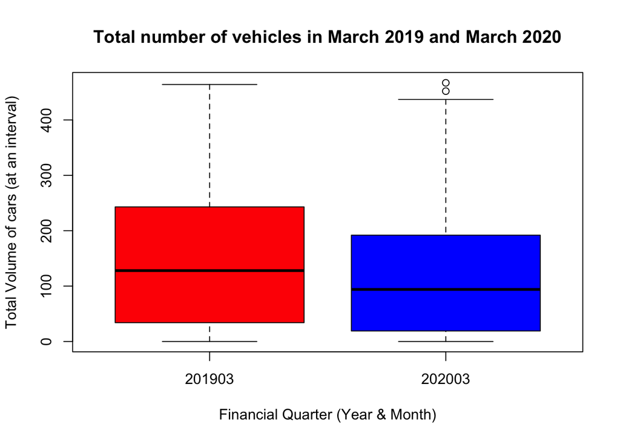

```r
# Boxplot
boxplot(TotalVolume ~ FinancialQtrID, data = df2, xlab = "Financial Quarter (Year & Month)", ylab = "Total Volume of cars (at an interval)", main = "Total number of vehicles in March 2019 and March 2020", col = c("red", "blue"))



# creating multiple bar plots in R
library(ggplot2)
```

[figure not shown]

```r
# creating a dummy dataset
number <- c(Avg_19, Avg_20)

gender <- c('Week 1', 'Week 2', 'Week 3', 'Week 4', 'Week 5')

friend_or_not <- c("2019", "2019", "2019", "2019", "2019", "2020", "2020", "2020", "2020","2020")

# creating data frame
circle <- data.frame(number,gender,friend_or_not)

# creating plot using the above data
ggplot(circle, aes(gender, number, fill = friend_or_not)) +
  geom_bar(stat="identity", position = "dodge") +
  labs(title="Multiple Bar plots")
```

```r
Diff = Avg_19-Avg_20
print(Diff)
```

```
## [1]  1.512897  3.064980 22.882440 60.236607 83.660590
```

```r
Restriction_Phase= c(1:5)
cor(Diff, Restriction_Phase)
```

```
## [1] 0.9628862
```

### 2.3.2 Conclusion

From the boxplot we can deduce that the mean of the volume of cars in the month of march is at an overall lower mean in 2020 compared to 2019. The inter-quarterly range of 2020 is also slightly smaller do to it being shifted down in the graph, indicating that less cars were going through the CCT during 2020, hence showing some correlation between the hit of the COVID pandemic and the amount of cars on the road

This was emphasized through the barplot used, which showed a very strong correlation to the results on the pandemic on Australian citizens, as it clearly shows as the weeks progressed and the aaverage amount of cars passing through the CCT tunnels evidently decreased, especially when the shutdown stages had began.

We also calculated the correlation between the differences of traffic between each week for each year and found the correlation to be approximately 0.962, indicating and supporting a strong correlation between the restrictions from the COVID pandemic and the amount of cars on the road.

From out conclusion, we can also deduce that the conclusion made in 2019 was slightly skewed as there might have been some bias affecting certain days due to these lockdown restrictions, make our conclusion for research question 1 slightly inaccurate.

Further research into the topic was down and found that, ‘The magnitude of COVID-19 was found to result in fewer crashes and injuries, as well as a reduction in road safety performance, but substantially greater serious accidents’ [3], with multiple other websites supporting these claims. The result of this could be due to the increased probability of people being able to speed due to less traffic congestion. This is quite interesting and could be useful for Transport authorities to analyse as although there are less cars on the road, that doesn’t necessarily mean that road rules should be eased. Transport authorities might need to employ more speed cameras on the road for better safety and reduce the amount of these serious accidents that might result in innocent deaths.

# 3 References

1. The Age (2018), ‘Sydney’s Peak Hour Project,’ The Age, Accessed: October 20 2023, https://www.theage.com.au/interactive/2018/peak-hour-project/bespoke-features/sydney-3.html?resizable=true&v=10 .
2. Storen, R., & Corrigan, N. (2020, October 23), COVID-19: a chronology of state and territory government announcements (up until 30 June 2020), Accessed October 19 2023, https://www.aph.gov.au/About_Parliament/Parliamentary_Departments/Parliamentary_Library/pubs/rp/rp2021/Chronologies/COVID-19StateTerritoryGovernmentAnnouncements
3. Ebraiham Shaik, MD., Ahmad S., (2022 September 9), An overview of the impact of COVID-19 on road traffic safety and travel behavior, Accessed October 20 2023, https://www.ncbi.nlm.nih.gov/pmc/articles/PMC9123801/